# Final Microarray data analysis done by Dmytro Pravdyvets

# Project summary

This is the final project of the second part of the course of Omics carried out by Alex Sanchez Pla, where the main goal is maily how to analyse Microarray data, learn how to obtain it and leaning how to use R and Rmd. The project consists of a report of an analysis of Microaray data of choice, which in my case is GSE114556.

## Summary of the data

The obligate intracellular bacterium Chlamydia trachomatis replicates in a cytosolic vacuole in human epithelial cells. Infection of human cells with C. trachomatis causes substantial changes to many host cell signalling pathways but the molecular basis of such influence is not well understood. Studies of gene transcription of the infected cell have shown altered transcription of many host cell genes, indicating a transcriptional response of the host cell to the infection. We here describe that infection of human cells with C. trachomatis as well as infection of murine cells with C. muridarum profoundly inhibits protein synthesis of the infected host cell. This inhibition was accompanied by changes to the ribosomal profile of the infected cell indicative of a block of translation initiation, most likely as part of a stress response. The chlamydial protease CPAF also reduced protein synthesis in uninfected cells although CPAF-deficient C. trachomatis showed no defect in this respect. Analysis of polysomal mRNA as a proxy of actively transcribed mRNA identified a number of biological processes differentially affected by chlamydial infection. Mapping of differentially regulated genes onto a protein interaction network identified nodes of up- and down-regulated networks during chlamydial infection. Proteomic analysis of protein synthesis further suggested translational regulation of host cell functions by chlamydial infection. These results demonstrate reprogramming of the host cell during chlamydial infection through the alteration of protein synthesis.

## Overall design

HeLa cells were infected with C. trachomatis L2 for 33h or left untreated and polysomal as well as total RNA was isolated.

## Citations

Ohmer M, Tzivelekidis T, Niedenführ N, Volceanov-Hahn L et al. Infection of HeLa cells with Chlamydia trachomatis inhibits protein synthesis and causes multiple changes to host cell pathways. Cell Microbiol 2019 Apr;21(4):e12993. PMID: 30551267

Loading all the needed packages before running the analysis

### Targets summary

We can see that the whole grou of observation can be divided into 12 samples, that can be grouped into 4 different subgroups, the division into subgroups will be later used as factors for regression model

```r
targets <- read.csv('./data/targets.csv', header = T,sep = ';')
targets
```

```
##    SampleName          grupos ShortNAme         Colors
## 1  GSM3143969 Infection_total      IT69     firebrick3
## 2  GSM3143970 Infection_total      IT70     firebrick3
## 3  GSM3143971 Infection_total      IT71     firebrick3
## 4  GSM3143972   Control_total      CT72          cyan3
## 5  GSM3143973   Control_total      CT73          cyan3
## 6  GSM3143974   Control_total      CT74          cyan3
## 7  GSM3143975 Infection_polyA      IP75      darkgreen
## 8  GSM3143976 Infection_polyA      IP76      darkgreen
## 9  GSM3143977 Infection_polyA      IP77      darkgreen
## 10 GSM3143978   Control_polyA      CP78 darkgoldenrod2
## 11 GSM3143979   Control_polyA      CP79 darkgoldenrod2
## 12 GSM3143980   Control_polyA      CP80 darkgoldenrod2
```

Loadign all the CEL files of the study that will be used for the analysis

Defining 2 varaibles of the targets file that will be used for plots later on

```r
sampleNames <- as.character(targets$ShortNAme)
sampleColor <- as.character(targets$Colors)
```

### Quality control of arrays with raw data

We begin to analyse data with a boxplot

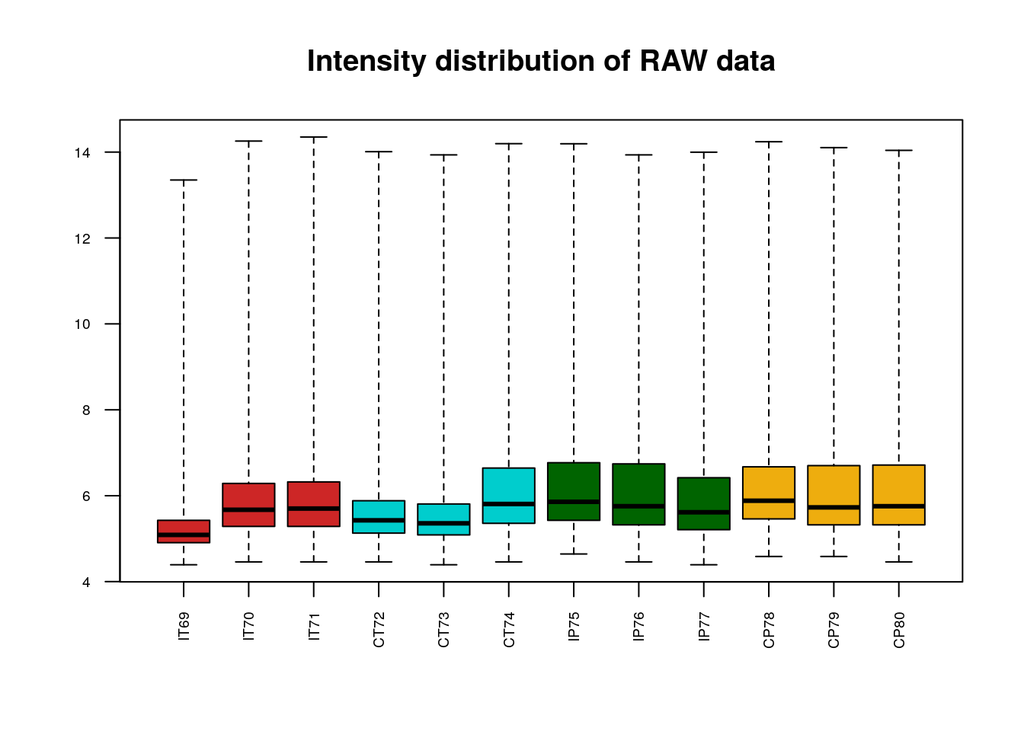

```r
boxplot(rawData, which="all",las=2, main="Intensity distribution of RAW data",
        cex.axis=0.6, col=sampleColor, names=sampleNames)
```

We can see that there not seem to be any artifacts with the data, but the distribution of the values seems to be somewhat different between the groups.

Next step would be to cluster the data

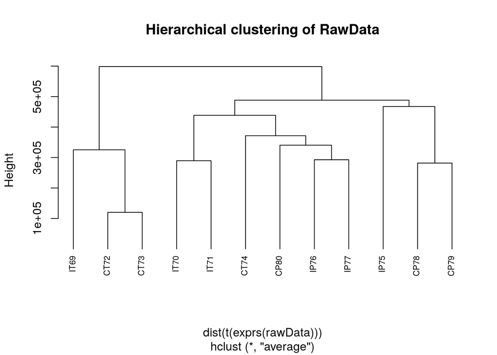

```r
clust.euclid.averageR <- hclust(dist(t(exprs(rawData))),method="average")
plot(clust.euclid.averageR, labels=sampleNames, main="Hierarchical clustering of RawData",
     cex=0.7,  hang=-1)
```

It looks like there are some clear clusters of data if we compare the clusters to the boxplots, similar boxplot end up in the same cluster ex(69,72,73).

Now we do the principar component analysis

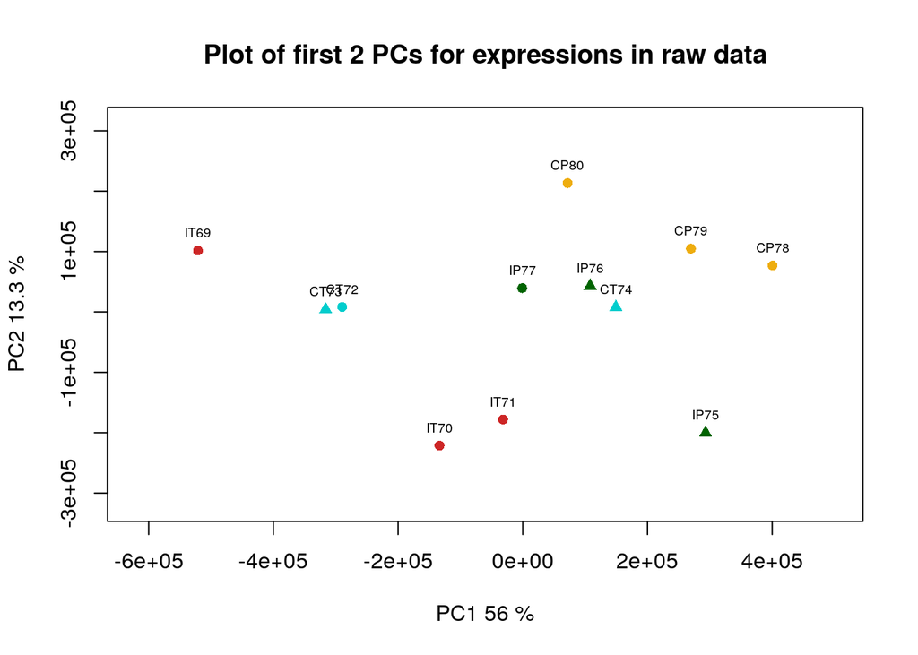

```r
plotPCA <- function ( X, labels=NULL, colors=NULL, dataDesc="", scale=FALSE, formapunts=NULL, myCex=0.8,...)
{
  pcX<-prcomp(t(X), scale=scale) # o prcomp(t(X))
  loads<- round(pcX$sdev^2/sum(pcX$sdev^2)*100,1)
  xlab<-c(paste("PC1",loads[1],"%"))
  ylab<-c(paste("PC2",loads[2],"%"))
  if (is.null(colors)) colors=1
  plot(pcX$x[,1:2],xlab=xlab,ylab=ylab, col=colors, pch=formapunts,
       xlim=c(min(pcX$x[,1])-100000, max(pcX$x[,1])+100000),ylim=c(min(pcX$x[,2])-100000, max(pcX$x[,2])+100000))
  text(pcX$x[,1],pcX$x[,2], labels, pos=3, cex=myCex)
  title(paste("Plot of first 2 PCs for expressions in", dataDesc, sep=" "), cex=0.8)
}

plotPCA(exprs(rawData), labels=sampleNames, dataDesc="raw data", colors=sampleColor,
        formapunts=c(rep(16,4),rep(17,4)), myCex=0.6)
```

By doing this we try to reduce the size of our datasaet without loosing too much information (the principal of PCA itself basically), we can see which PC (1 or 2) has more effect on a specific sample.

### Data normalization and analysis

Now we normalize our data and check if the results are now different or same and if the normalization is okay without artifacts.

Once data is normalized, we repeat the analysis done before and compare the results

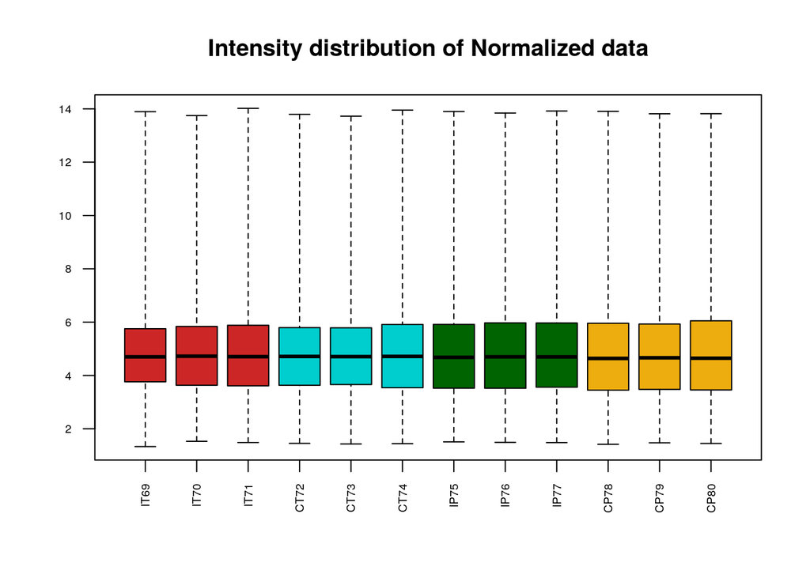

```r
#BOXPLOT
boxplot(eset, las=2, main="Intensity distribution of Normalized data", cex.axis=0.6,
        col=sampleColor, names=sampleNames)
```

Now we can see that the data has barely any difference, being someone with little experience in this field, I do not have a concrete answer, but after looking up things on internet and just intuevly, the fact that the data is so stabilized now is strange.

Next step is to cluster the observations

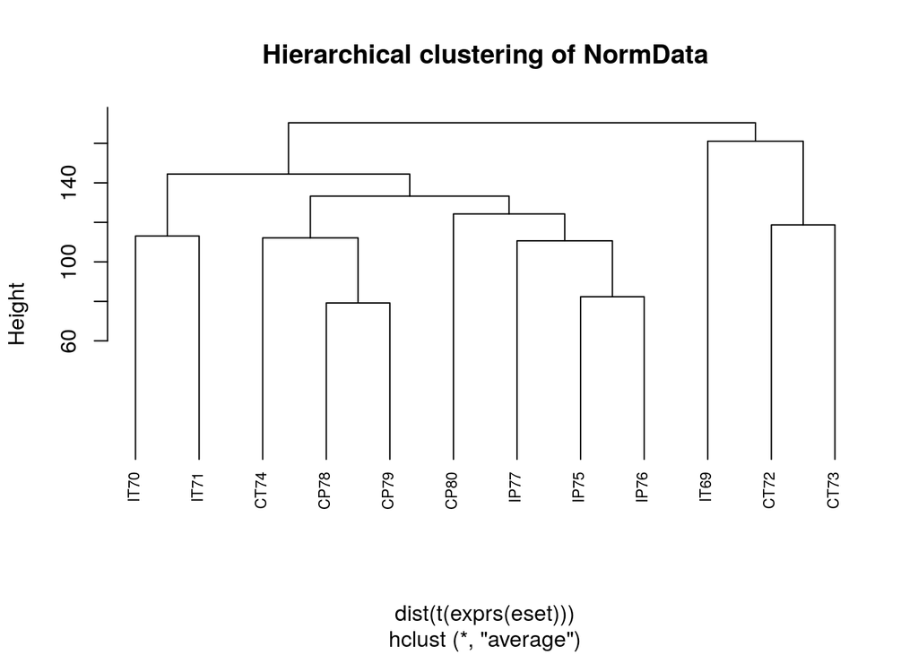

```r
clust.euclid.averageN <- hclust(dist(t(exprs(eset))),method="average")
plot(clust.euclid.averageN, labels=sampleNames, main="Hierarchical clustering of NormData",
     cex=0.7,  hang=-1)
```

Last step is to again analyze principal components

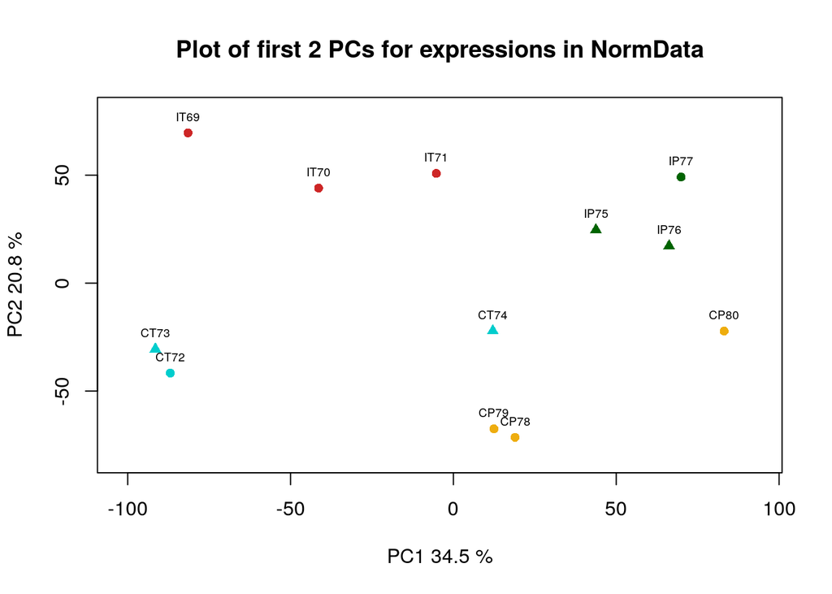

```r
plotPCA <- function ( X, labels=NULL, colors=NULL, dataDesc="", scale=FALSE, formapunts=NULL, myCex=0.8,...)
{
  pcX<-prcomp(t(X), scale=scale) # o prcomp(t(X))
  loads<- round(pcX$sdev^2/sum(pcX$sdev^2)*100,1)
  xlab<-c(paste("PC1",loads[1],"%"))
  ylab<-c(paste("PC2",loads[2],"%"))
  if (is.null(colors)) colors=1
  plot(pcX$x[,1:2],xlab=xlab,ylab=ylab, col=colors, pch=formapunts,
       xlim=c(min(pcX$x[,1])-10, max(pcX$x[,1])+10),ylim=c(min(pcX$x[,2])-10, max(pcX$x[,2])+10))
  text(pcX$x[,1],pcX$x[,2], labels, pos=3, cex=myCex)
  title(paste("Plot of first 2 PCs for expressions in", dataDesc, sep=" "), cex=0.8)
}

plotPCA(exprs(eset), labels=sampleNames, dataDesc="NormData", colors=sampleColor,
        formapunts=c(rep(16,4),rep(17,4)), myCex=0.6)
```

Here is where we can see more difference, some previous points differ a lot and because of normalization, the scale of the graph is smaller too, so the previous one was better for this

### Array quality matrices

Now we are going to filter our data and check it’s quality

After the filtering,the amount of genes that are out is:

```r
print(eset_filtered$filter.log$numLowVar)
```

```
## [1] 40213
```

And the rest of the genes with the characteristic of the dataset can be obtained from here:

```r
print(eset_filtered$eset)
```

```
## ExpressionSet (storageMode: lockedEnvironment)
## assayData: 13404 features, 12 samples
##   element names: exprs
## protocolData
##   rowNames: GSM3143969_Infection_tot_rep1.CEL
##     GSM3143970_Infection_tot_rep2.CEL ...
##     GSM3143980_Ctl_poly_rep3.CEL (12 total)
##   varLabels: exprs dates
##   varMetadata: labelDescription channel
## phenoData
##   rowNames: GSM3143969_Infection_tot_rep1.CEL
##     GSM3143970_Infection_tot_rep2.CEL ...
##     GSM3143980_Ctl_poly_rep3.CEL (12 total)
##   varLabels: index
##   varMetadata: labelDescription channel
## featureData: none
## experimentData: use 'experimentData(object)'
## Annotation: org.Mm.eg.db
```

### Differential expressed genes, regression and plots

Now the analysis itself is going to be done, using differentially expressed genes, regression models and plots

```r
treat <- targets$grupos
lev <- factor(treat, levels = unique(treat))
design <-model.matrix(~0+lev)
colnames(design)<-c("it","ct","ip","cp")
rownames(design) <- sampleNames
print(design)
```

```
##      it ct ip cp
## IT69  1  0  0  0
## IT70  1  0  0  0
## IT71  1  0  0  0
## CT72  0  1  0  0
## CT73  0  1  0  0
## CT74  0  1  0  0
## IP75  0  0  1  0
## IP76  0  0  1  0
## IP77  0  0  1  0
## CP78  0  0  0  1
## CP79  0  0  0  1
## CP80  0  0  0  1
## attr(,"assign")
## [1] 1 1 1 1
## attr(,"contrasts")
## attr(,"contrasts")$lev
## [1] "contr.treatment"
```

Here you can see the design model of the data, which has 4 different Alphas where each alpha has 3 samples

Creating contrast matrix

```r
cont.matrix1 <- makeContrasts (
  itvsct = it-ct,
  itvsip = it-ip,
  itvscp = it-cp,
  ctvsip = ct-ip,
  ctvscp = ct-cp,
  ipvscp = ip-cp,
  levels=design)
comparison1 <- "Infection or control vs polyA or Total"
cont.matrix1
```

```
##       Contrasts
## Levels itvsct itvsip itvscp ctvsip ctvscp ipvscp
##     it      1      1      1      0      0      0
##     ct     -1      0      0      1      1      0
##     ip      0     -1      0     -1      0      1
##     cp      0      0     -1      0     -1     -1
```

Now we have both matrices, next step is to fit the data to a model

```r
fit1 <- lmFit(eset_filtered$eset, design)
fit.main1 <- contrasts.fit(fit1, cont.matrix1)
fit.main1
```

[output not shown]

[output cut: 45 more lines]

```
##      it ct ip cp
## IT69  1  0  0  0
## IT70  1  0  0  0
## IT71  1  0  0  0
## CT72  0  1  0  0
## CT73  0  1  0  0
## 7 more rows ...
##
## $contrasts
##       Contrasts
## Levels itvsct itvsip itvscp ctvsip ctvscp ipvscp
##     it      1      1      1      0      0      0
##     ct     -1      0      0      1      1      0
##     ip      0     -1      0     -1      0      1
##     cp      0      0     -1      0     -1     -1
```

Another good idea is to account for bayeses in the model, for this we can run this code:

```r
fit.main1 <- eBayes(fit.main1)
fit.main1
```

[output not shown]

[output cut: 118 more lines]

```
##               itvsct    itvsip    itvscp    ctvsip    ctvscp    ipvscp
##   16650001 -4.901805 -6.191728 -6.008314 -5.198855 -5.992619 -5.879790
##   16650005 -6.196465 -5.736964 -6.256128 -6.445594 -6.178153 -6.384047
##   16650011 -5.686479 -4.285418 -1.458400 -6.095351 -3.230593 -4.874366
##   16650013 -5.865497 -5.215862 -6.126336 -4.025716 -4.491279 -6.285436
##   16650015 -6.191846 -4.966236 -6.616983 -4.420616 -6.032906 -5.210236
## 13399 more rows ...
##
## $F
## [1] 1.4328995 0.3641152 5.4021077 2.3105982 1.7548786
## 13399 more elements ...
##
## $F.p.value
## [1] 0.28186591 0.78015638 0.01389058 0.12820049 0.20926168
## 13399 more elements ...
```

### Toptables of the genes

We already have the matrices, model and data, so we can get the toptables for each comparison

```r
topTab_itvsct <- topTable (fit.main1, number=nrow(fit.main1), coef="itvsct", adjust="fdr");
head(topTab_itvsct)
```

```
##              logFC  AveExpr          t      P.Value    adj.P.Val        B
## 17010760  3.341864 7.321204  13.058204 1.920098e-08 0.0002573699 9.028414
## 16665240  3.410890 7.518821  11.058864 1.218651e-07 0.0008167402 7.607752
## 16774303 -2.953147 8.685349 -10.328521 2.569533e-07 0.0011480671 7.001314
## 16984689  2.774378 5.905409   9.554674 5.944427e-07 0.0016185250 6.299183
## 16967831  2.887011 6.482892   9.405846 7.028003e-07 0.0016185250 6.156592
## 16808712  3.156968 6.033338   9.379018 7.244964e-07 0.0016185250 6.130618
```

```r
topTab_itvsip <- topTable (fit.main1, number=nrow(fit.main1), coef="itvsip", adjust="fdr"); head(topTab_itvsip)
```

```
##             logFC  AveExpr         t      P.Value   adj.P.Val        B
## 17093722 5.421280 6.255092 10.106363 3.251771e-07 0.004358674 6.496344
## 16653197 2.802081 5.649028  8.191979 2.988088e-06 0.020026164 4.717664
## 16653533 2.939939 4.633059  7.468775 7.635417e-06 0.024457911 3.921483
## 16874508 1.932136 8.868661  7.109989 1.244600e-05 0.024457911 3.497953
## 16874510 1.932136 8.868661  7.109989 1.244600e-05 0.024457911 3.497953
## 17118411 1.929860 6.379718  7.091284 1.277271e-05 0.024457911 3.475334
```

```r
topTab_itvscp <- topTable (fit.main1, number=nrow(fit.main1), coef="itvscp", adjust="fdr"); head(topTab_itvsct)
```

```
##              logFC  AveExpr          t      P.Value    adj.P.Val        B
## 17010760  3.341864 7.321204  13.058204 1.920098e-08 0.0002573699 9.028414
## 16665240  3.410890 7.518821  11.058864 1.218651e-07 0.0008167402 7.607752
## 16774303 -2.953147 8.685349 -10.328521 2.569533e-07 0.0011480671 7.001314
## 16984689  2.774378 5.905409   9.554674 5.944427e-07 0.0016185250 6.299183
## 16967831  2.887011 6.482892   9.405846 7.028003e-07 0.0016185250 6.156592
## 16808712  3.156968 6.033338   9.379018 7.244964e-07 0.0016185250 6.130618
```

```r
topTab_ctvsip <- topTable (fit.main1, number=nrow(fit.main1), coef="ctvsip", adjust="fdr"); head(topTab_ctvsip)
```

```
##              logFC  AveExpr         t      P.Value    adj.P.Val        B
## 17010760 -3.215828 7.321204 -12.56572 2.955432e-08 0.0003125140 9.106255
## 16900018  5.798473 5.415258  12.06262 4.662996e-08 0.0003125140 8.725046
## 16984689 -3.294409 5.905409 -11.34561 9.194538e-08 0.0004108120 8.146160
## 16899476  3.145431 7.072982  10.77999 1.612272e-07 0.0004599042 7.657705
## 16732755 -2.375713 7.044144 -10.67859 1.787667e-07 0.0004599042 7.566992
## 16874508  2.810112 8.868661  10.34082 2.536564e-07 0.0004599042 7.257640
```

```r
topTab_ctvscp <- topTable (fit.main1, number=nrow(fit.main1), coef="ctvscp", adjust="fdr"); head(topTab_ctvscp)
```

```
##              logFC  AveExpr         t      P.Value  adj.P.Val        B
## 17107640 -2.722420 3.668552 -8.454892 2.155887e-06 0.01123003 5.026314
## 16993422 -1.954992 9.072176 -8.245207 2.795297e-06 0.01123003 4.808156
## 16900018  3.940155 5.415258  8.196747 2.970253e-06 0.01123003 4.756895
## 16653197  2.770969 5.649028  8.101022 3.351248e-06 0.01123003 4.654694
## 17093722  4.094735 6.255092  7.633415 6.134014e-06 0.01216477 4.136992
## 16771492 -3.498223 7.511582 -7.626624 6.189268e-06 0.01216477 4.129242
```

```r
topTab_ipvscp <- topTable (fit.main1, number=nrow(fit.main1), coef="ipvscp", adjust="fdr"); head(topTab_ipvscp )
```

```
##              logFC  AveExpr          t      P.Value    adj.P.Val        B
## 17010760  3.360535 7.321204  13.131158 1.803458e-08 0.0002417355 9.182352
## 16909021  2.768598 7.179230  10.738033 1.682496e-07 0.0011276089 7.417569
## 16774303 -2.871372 8.685349 -10.042519 3.482132e-07 0.0011326880 6.808153
## 16984689  2.873085 5.905409   9.894610 4.085994e-07 0.0011326880 6.672116
## 17005865 -2.969470 5.480765  -9.863850 4.225187e-07 0.0011326880 6.643530
## 16887702  2.208945 8.278752   9.334353 7.622289e-07 0.0015359529 6.135065
```

Here we join the most differential genes of all the topTables into 1, which will be used for plots and annotation

```r
topTab<-do.call('rbind',list(topTab_itvscp[1:round(NROW(topTab_itvscp)*0.05),],topTab_itvsct[1:round(NROW(topTab_itvsct)*0.05),],topTab_itvsip[1:round(NROW(topTab_itvsip)*0.05),],topTab_ctvscp[1:round(NROW(topTab_ctvscp)*0.05),],topTab_ctvsip[1:round(NROW(topTab_ctvsip)*0.05),],topTab_ipvscp[1:round(NROW(topTab_ipvscp)*0.05),]))
```

### Volcano plot

Creating volcano plot of top differentially expressed genes

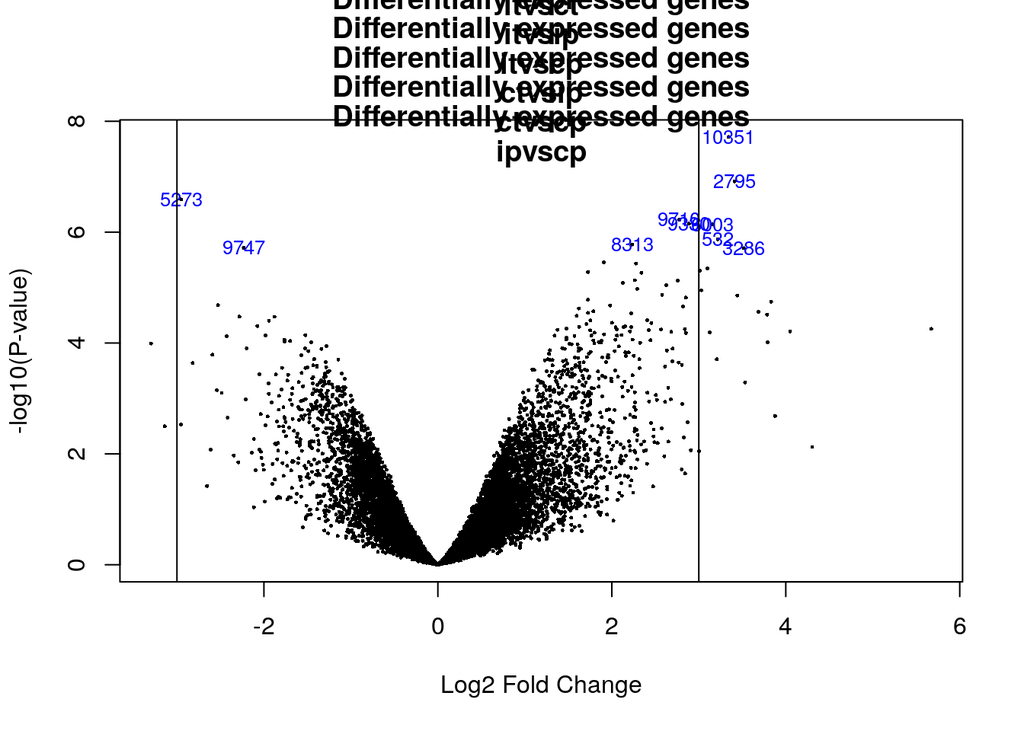

```r
volcanoplot(fit.main1, highlight=10, names=fit.main1$ID,
            main = paste("Differentially expressed genes", colnames(cont.matrix1), sep="\n"))
abline(v = c(-3, 3))
```

### Prepare data for heatmap and make the plot

Creating heatmap of the data

```r
my_frame <- data.frame(exprs(eset))
HMdata <- merge(my_frame, topTab, by.x = 0, by.y = 0)
rownames(HMdata) <- HMdata$Row.names
HMdata <- HMdata[, -c(1,10:15)]
HMdata2 <- data.matrix(HMdata, rownames.force=TRUE)
```

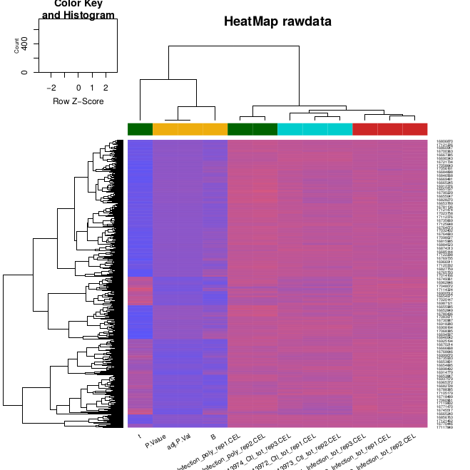

Heatmap

### Annotating the obtained genes

The annotated genes are going to be written in annotation.csv. To get rid of the duplicates, use file “unique”, by “bash unique”.